# IODS course project

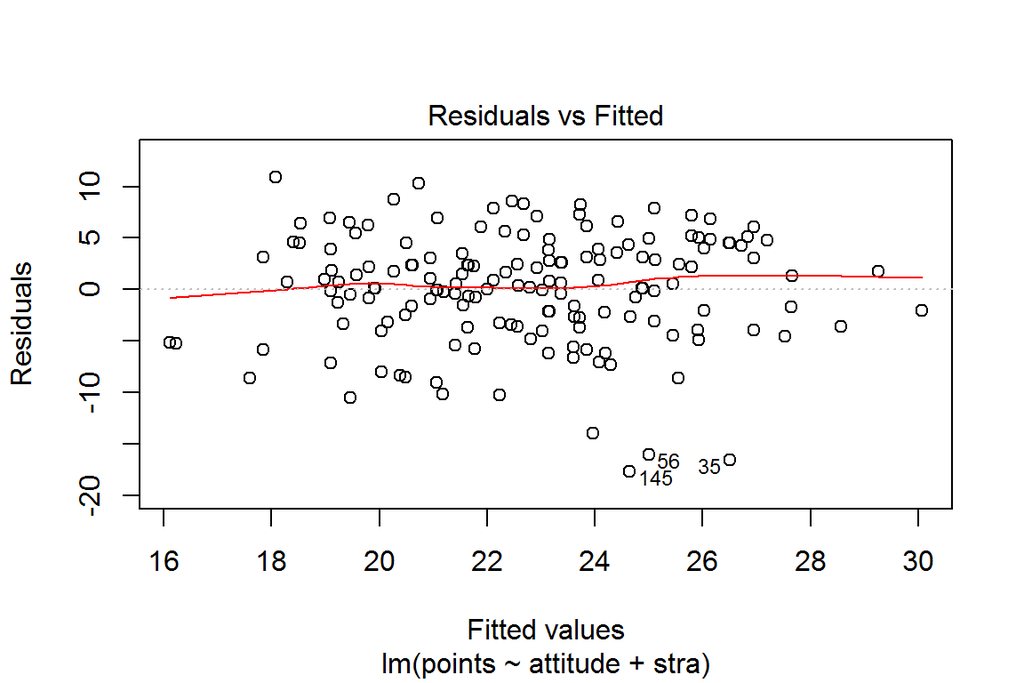

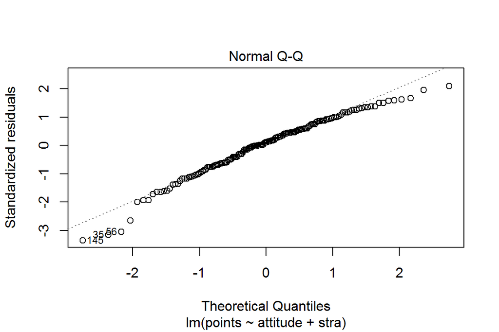

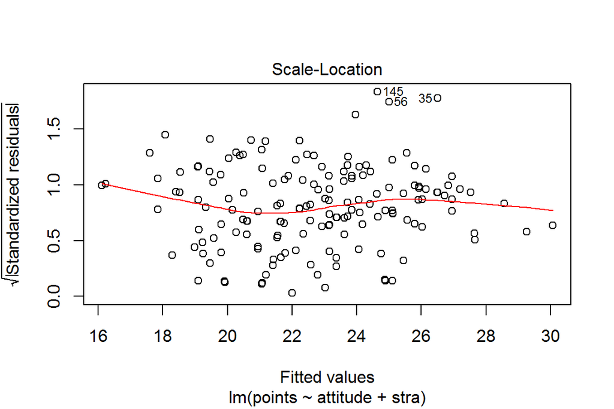

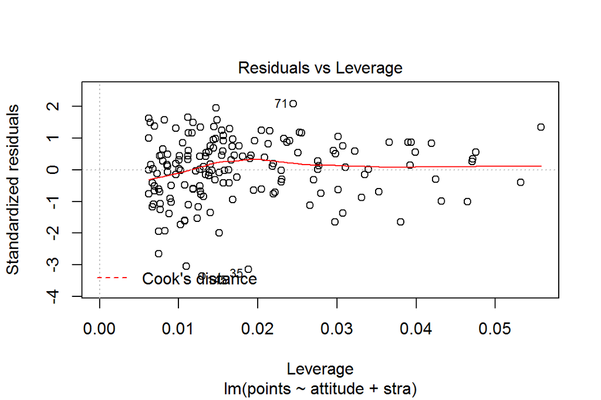

```r
plot(my_model21)
```

The four residual plots show potential problematic cases with the row numbers of the data in the dataset.

**Residuals versus Fitted values plot** should not show any patterns. This is a case for both investigated models. Few outliers could be fixed on these graphics for both models: observations #35, #56 and #145 are fixed as possible outliers for both regression models. If we see any shape (curve, U-shape), it suggests non-linearity in the data set. If a tunnel shape pattern occur, this means that data suffer from heteroskedansticity, where error terms have non-constant variance.

**Normality Q-Q plot** is used to determine the normal distribution of errors. It uses standardized values (normal quantile) of residuals. In ideal case this plot should show a straight line. Otherwise the residuals have a non-normal distribution. In both investigated models this plot could be approximated to straight line. Again observations #35, #56 and #145 are fixed as possible outliers.

**Scale-location plot** is also useful to determine heteroskedansticity. In ideal case it should not show any pattern. In both investigated models this plot does not show any pattern. gain observations #35, #56 and #145 are fixed as possible outliers.

**Residuals versus leverage plot** helps us to find influential cases (i.e., subjects) if any. Not all outliers are influential in linear regression analysis. Unlike the other plots, here patterns are not relevant. We watch out for outlying values at the upper right corner or at the lower right corner. Those spots are the places where cases can be influential against a regression line. Look for cases outside of a dashed line, Cook’s distance. When cases are outside of the Cook’s distance (meaning they have high Cook’s distance scores), the cases are influential to the regression results. The regression results will be altered if we exclude those cases.

Before to make decision about these points we have to check how influential they are on the model by excluding them from data set and performing parameter estimation again. Next we have to compare the summary results and conclude about the impact of these points on parameter estimation.

As we see from residual plots for both simple and multiple regression models, the results are very similar for the single regression **points ~ attitude**, and multiple regression **points ~ attitude + stra**. As including more variables is assumed to be a better approach, the final modeling choice is a multiple regression **points ~ attitude + stra**.

## Useful links

[Meaning of all coefficients, given in summary for linear regression (lm)] (http://blog.yhat.com/posts/r-lm-summary.html)

[Article about ggplot and ggpairs] (http://vita.had.co.nz/papers/gpp.pdf)

[Beginners guide to regression] (http://blog.hackerearth.com/beginners-guide-regression-analysis-plot-interpretations)

[Understanding Diagnostic Plots for Linear Regression Analysis](http://data.library.virginia.edu/diagnostic-plots/)

## Link to to the GitHub page, related to my work on this course:

https://github.com/noykova/IODS-project

# 3. Logistic regression

## 3.1 Reading the data

Here we use modified student alcohol consumption data described [here](https://archive.ics.uci.edu/ml/datasets/STUDENT+ALCOHOL+CONSUMPTION).

The joined data set used in the analysis exercise combines the two student alcohol consumption data sets. The following adjustments have been made:

- The variables not used for joining the two data have been combined by averaging (including the grade variables)
- ‘alc_use’ is the average of ‘Dalc’ and ‘Walc’
- ‘high_use’ is TRUE if ‘alc_use’ is higher than 2 and FALSE otherwise

The R code about wrangling described above is given [here](https://github.com/noykova/IODS-project/blob/master/Data/create_alc.R)

The data are read using the following command:

```r
alc<- read.table("alc.txt", header=TRUE)
dim(alc)
```

```
## [1] 382  35
```

```r
str(alc)
```

```
## 'data.frame':    382 obs. of  35 variables:
##  $ school    : Factor w/ 2 levels "GP","MS": 1 1 1 1 1 1 1 1 1 1 ...
##  $ sex       : Factor w/ 2 levels "F","M": 1 1 1 1 1 2 2 1 2 2 ...
##  $ age       : int  18 17 15 15 16 16 16 17 15 15 ...
##  $ address   : Factor w/ 2 levels "R","U": 2 2 2 2 2 2 2 2 2 2 ...
##  $ famsize   : Factor w/ 2 levels "GT3","LE3": 1 1 2 1 1 2 2 1 2 1 ...
##  $ Pstatus   : Factor w/ 2 levels "A","T": 1 2 2 2 2 2 2 1 1 2 ...
##  $ Medu      : int  4 1 1 4 3 4 2 4 3 3 ...
##  $ Fedu      : int  4 1 1 2 3 3 2 4 2 4 ...
##  $ Mjob      : Factor w/ 5 levels "at_home","health",..: 1 1 1 2 3 4 3 3 4 3 ...
##  $ Fjob      : Factor w/ 5 levels "at_home","health",..: 5 3 3 4 3 3 3 5 3 3 ...
##  $ reason    : Factor w/ 4 levels "course","home",..: 1 1 3 2 2 4 2 2 2 2 ...
##  $ nursery   : Factor w/ 2 levels "no","yes": 2 1 2 2 2 2 2 2 2 2 ...
##  $ internet  : Factor w/ 2 levels "no","yes": 1 2 2 2 1 2 2 1 2 2 ...
##  $ guardian  : Factor w/ 3 levels "father","mother",..: 2 1 2 2 1 2 2 2 2 2 ...
```

[output cut: 21 more lines]

```r
head(alc)
```

```
##   school sex age address famsize Pstatus Medu Fedu     Mjob     Fjob
## 1     GP   F  18       U     GT3       A    4    4  at_home  teacher
## 2     GP   F  17       U     GT3       T    1    1  at_home    other
## 3     GP   F  15       U     LE3       T    1    1  at_home    other
## 4     GP   F  15       U     GT3       T    4    2   health services
## 5     GP   F  16       U     GT3       T    3    3    other    other
## 6     GP   M  16       U     LE3       T    4    3 services    other
##       reason nursery internet guardian traveltime studytime failures
## 1     course     yes       no   mother          2         2        0
## 2     course      no      yes   father          1         2        0
## 3      other     yes      yes   mother          1         2        2
## 4       home     yes      yes   mother          1         3        0
## 5       home     yes       no   father          1         2        0
## 6 reputation     yes      yes   mother          1         2        0
##   schoolsup famsup paid activities higher romantic famrel freetime goout
## 1       yes     no   no         no    yes       no      4        3     4
## 2        no    yes   no         no    yes       no      5        3     3
## 3       yes     no  yes         no    yes       no      4        3     2
## 4        no    yes  yes        yes    yes      yes      3        2     2
## 5        no    yes  yes         no    yes       no      4        3     2
## 6        no    yes  yes        yes    yes       no      5        4     2
##   Dalc Walc health absences G1 G2 G3 alc_use high_use
## 1    1    1      3        5  2  8  8     1.0    FALSE
## 2    1    1      3        3  7  8  8     1.0    FALSE
## 3    2    3      3        8 10 10 11     2.5     TRUE
## 4    1    1      5        1 14 14 14     1.0    FALSE
## 5    1    2      5        2  8 12 12     1.5    FALSE
## 6    1    2      5        8 14 14 14     1.5    FALSE
```

```r
colnames(alc)
```

```
##  [1] "school"     "sex"        "age"        "address"    "famsize"
##  [6] "Pstatus"    "Medu"       "Fedu"       "Mjob"       "Fjob"
## [11] "reason"     "nursery"    "internet"   "guardian"   "traveltime"
## [16] "studytime"  "failures"   "schoolsup"  "famsup"     "paid"
## [21] "activities" "higher"     "romantic"   "famrel"     "freetime"
## [26] "goout"      "Dalc"       "Walc"       "health"     "absences"
## [31] "G1"         "G2"         "G3"         "alc_use"    "high_use"
```

## 3.2. Choice of depending variables, which affect alcohol consumption

The purpose of this analysis is to study the relationships between **high/low alcohol consumption** and some of the other variables in the data.

From phisiology is known that the alcohol has different influence on male and females. Therefore we assume **sex** as important dependent variable to be investigated further.

If the student has a problem with the alcohol, he or she surely will tend to skip the school classes more often. So, the secont dependent variable we choose to be **absence**.

Alcohol consumption surely will influence the sdudent grades, which quantify the success of study process. Thus we chose the **grades** as third dependent variable.

At this stage we find logical to assume that the alcohol consumption is influenced by the **freetime**. If the students have more free time,they will have more possibilities to go to the parties or to have other activities with alcohol consumption.

## 3.3. Cross-tabulations, bar plots and box plots for investigating the relationships between alcohol consumptions and the chosen dependent variables.

### Box plots

The box plot (box, whisker diagram) is a standardized way of displaying the distribution of data based on the five number summary: minimum, first quartile, median, third quartile, and maximum. In the simplest box plot the central rectangle spans the first quartile to the third quartile (the interquartile range or IQR). A segment inside the rectangle shows the median and “whiskers” above and below the box show the locations of the minimum and maximum. Values outside the whiskers can be considered as outliers, unusually distant observations.

Here we use box-plot analyses, provided in DataCamp exercise, and add two additional plots aiming to clarify the influence on free time on alcohol consumptions, grades and absences.

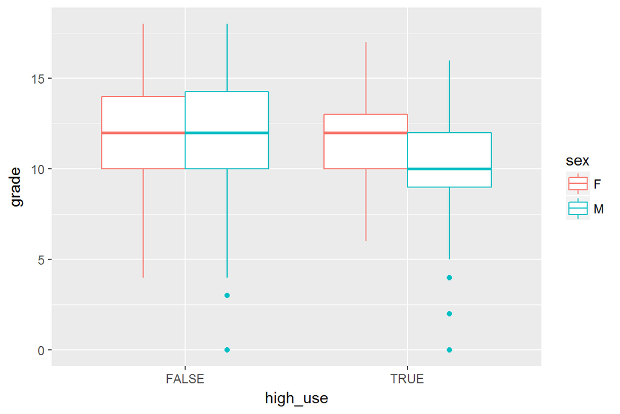

```r
library(GGally)
library(ggplot2)
g1 <- ggplot(alc, aes(x = high_use, y = G3, col=sex))
g1 + geom_boxplot() + ylab("grade")
```

We see that the distributions of grades for male and female students who have high consumption of alcohol,have different medians and deviations.

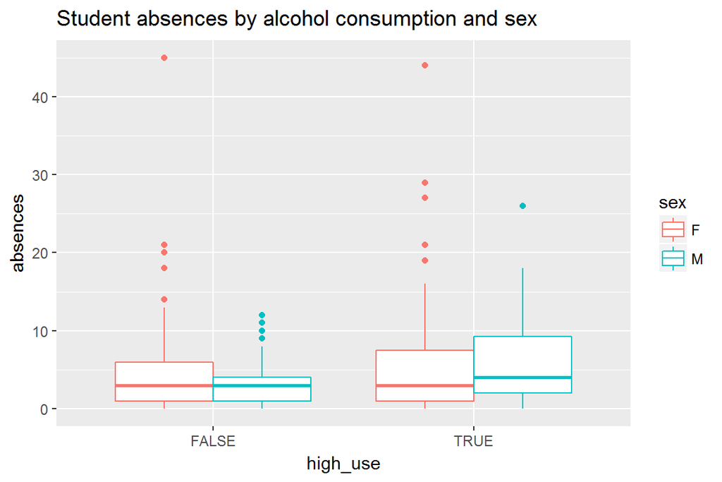

```r
g2 <- ggplot(alc, aes(x = high_use, y = absences, col=sex)) + ggtitle("Student absences by alcohol consumption and sex")

g2 + geom_boxplot() + ylab("absences")
```

This plot shows that the distributions of absences for male and female students who have high consumption of alcohol, have different medians and deviations.

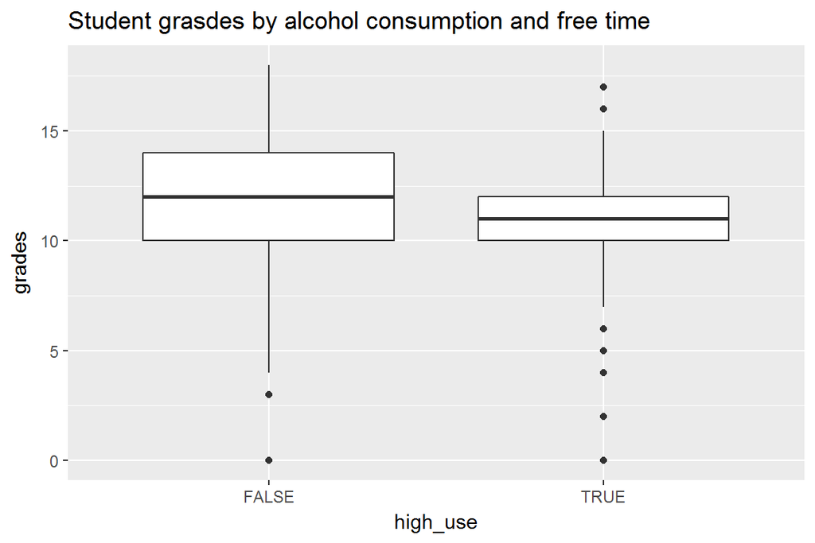

```r
g3 <- ggplot(alc, aes(x = high_use, y = G3, col=freetime)) + ggtitle("Student grasdes by alcohol consumption and free time")

g3 + geom_boxplot() + ylab("grades")
```

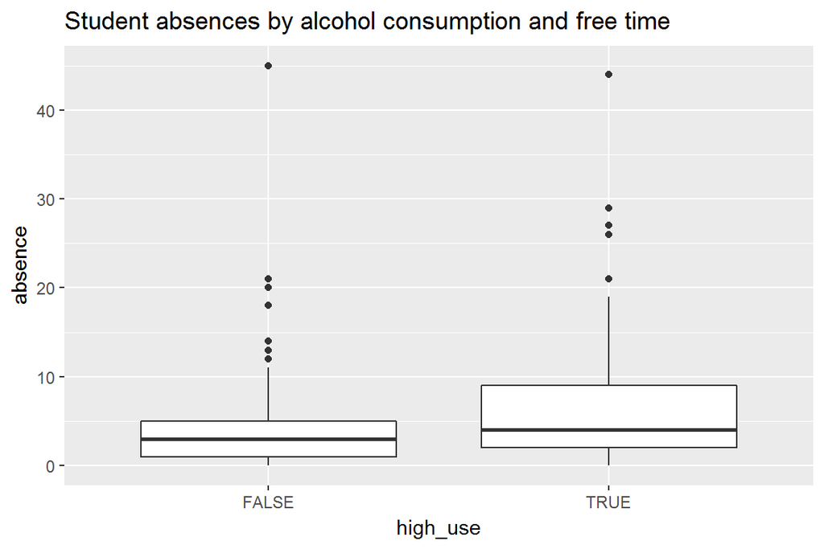

```r
g4 <- ggplot(alc, aes(x = high_use, y = absences, col=freetime)) + ggtitle("Student absences by alcohol consumption and free time")


g4 + geom_boxplot() + ylab("absence")
```

From these plots becomse clear that it is logical to assume sex, absence, grade and free time as variables, which could be assumed to have high impact on alcohol consumption.

### Bar plots

In previous chapter 2. we have used a plot matix to roughly estimate the dependences between different variables in the model. This was possible because the output variable was continuous.

Here the output varable high_use is binary and theefore we should explore another techniques.

Bar plots are one of the most commonly used kind of data visualization. They are used to display numeric values (on the y-axis), for different categories (on the x-axis).

Bar plots need not be based on counts or frequencies. We can create bar plots that represent means, medians, standard deviation. Then we have tuo use the aggregate( ) function and pass the results to the barplot( ) function.

Here we have examined the counts of different variables on y-axes. The grouped plots below present the counts of four dependent variables. The alcohol consumption is given as fill:

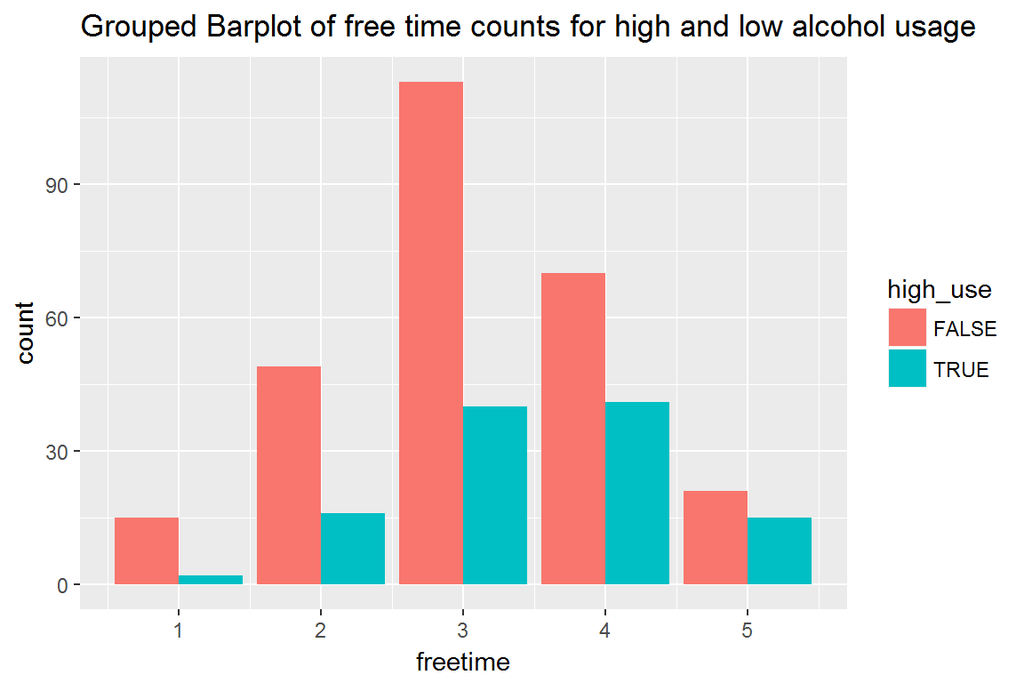

```r
bp <- ggplot(alc, aes(freetime, fill=high_use)) + geom_bar(position="dodge") +
  ggtitle("Grouped Barplot of free time counts for high and low alcohol usage")
bp
```

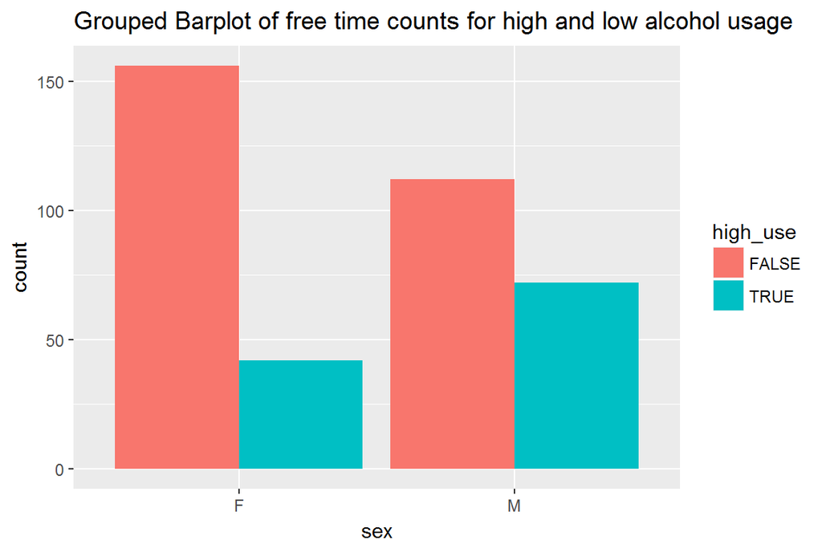

```r
bp2 <- ggplot(alc, aes(sex, fill=high_use)) + geom_bar(position="dodge") +
  ggtitle("Grouped Barplot of free time counts for high and low alcohol usage")
bp2
```

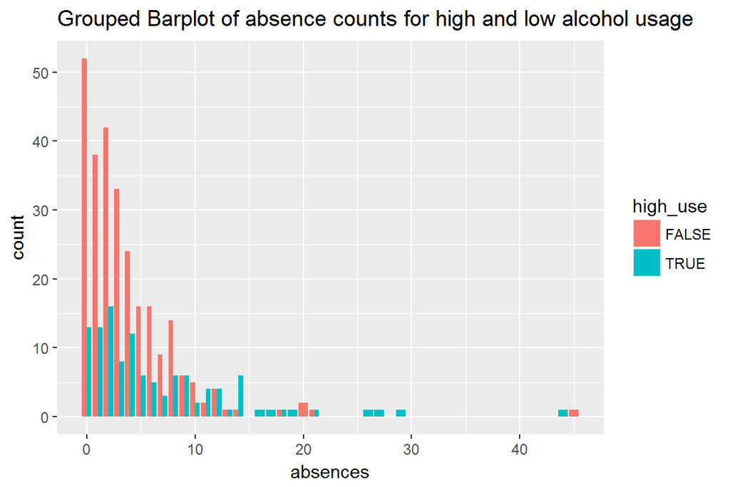

```r
bp3 <- ggplot(alc, aes(absences, fill=high_use)) + geom_bar(position="dodge") +
  ggtitle("Grouped Barplot of absence counts for high and low alcohol usage")
bp3
```

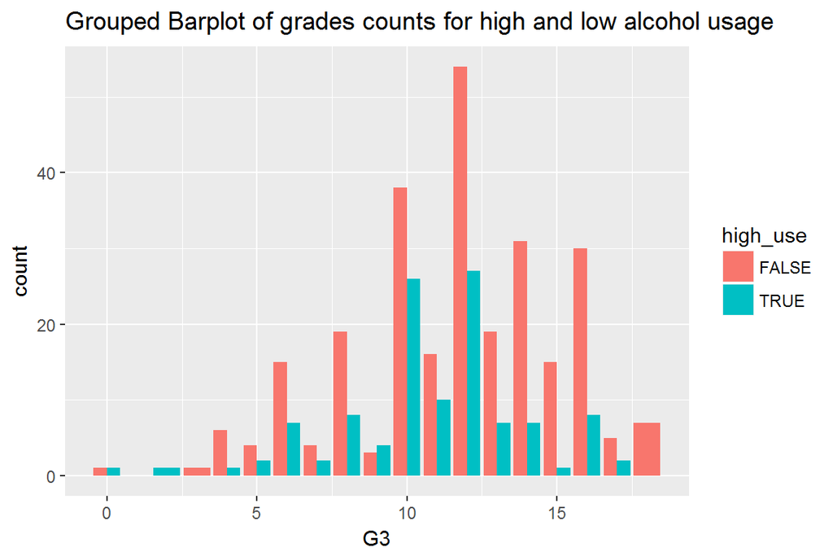

```r
bp4 <- ggplot(alc, aes(G3, fill=high_use)) + geom_bar(position="dodge") +
  ggtitle("Grouped Barplot of grades counts for high and low alcohol usage")
bp4
```

The bar graph of free time counts show that the use of alcohol is higer for gigher values of free time values. Az expected for higher number of absences the use of alcohol is higher.

Next bar plot shows the sependence of grades on high use of alcohol and free time. It is clear that students who have more free time tends to use alcohol and get lower grades.

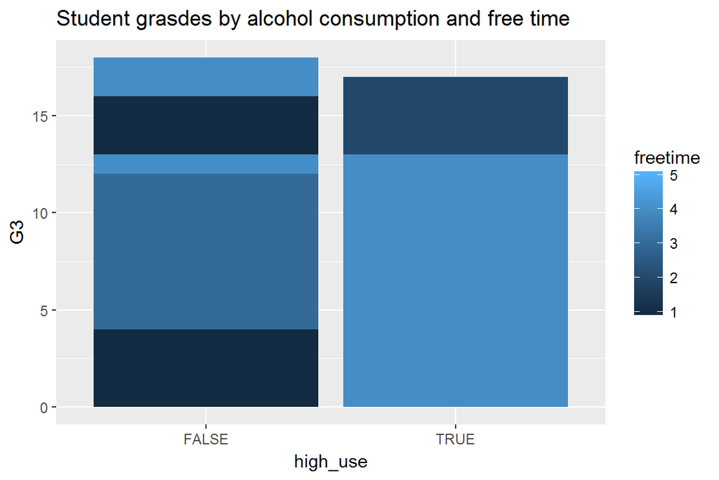

```r
b2 <- ggplot(alc, aes(x=high_use, y=G3, fill=freetime)) +
  geom_bar(stat="identity", position=position_dodge()) +
  ggtitle("Student grasdes by alcohol consumption and free time")
b2
```

Similar graph is drawn for the abcebses. Here is more clear that the students, who use alcohol have both more free time and bigger number of ancenses.

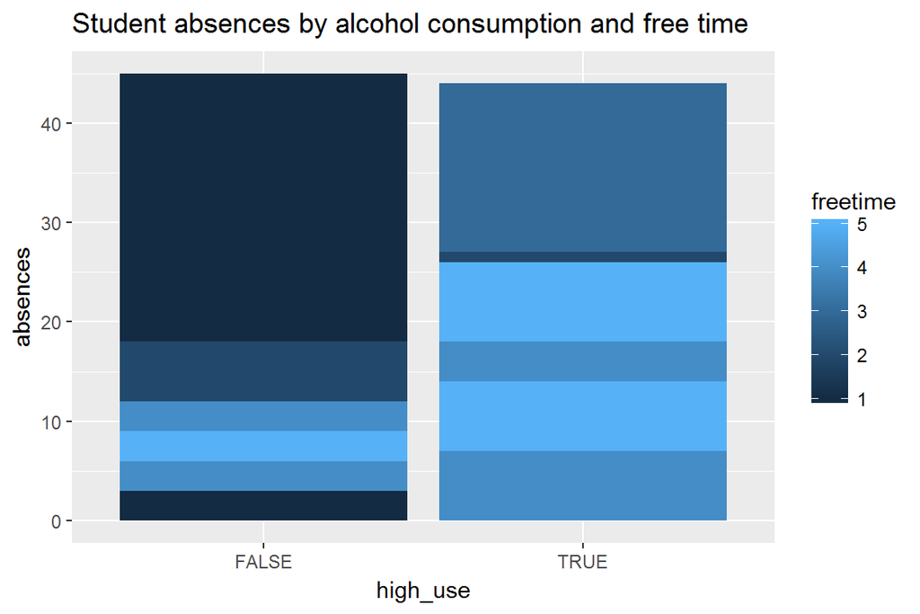

```r
#dependence of absences on high_use and sex.
b3 <- ggplot(alc, aes(x=high_use, y=absences, fill=freetime)) +
  geom_bar(stat="identity", position=position_dodge()) +
  ggtitle("Student absences by alcohol consumption and free time")
# draw the plot
b3
```

### Cross-tabulations (contingency table)

Cross tabulations are type of tables in a matrix format that displays the (multivariate) frequency distribution of the variables. They provide a basic picture of the interrelation between two variables and can help find interactions between them.

In CrossTable() function we can control whether row percentages (prop.r), column percentages (prop.c), or table percentages (prop.t) show up by making them TRUE in the call to CrossTable. Chi - square distribution is also shown.

We construct cross tables for all dependent variables.

```r
library(descr)
CrossTable(alc$freetime,alc$high_use, prop.t=TRUE, prop.r=TRUE, prop.c=TRUE)
```

```
##    Cell Contents
## |-------------------------|
## |                       N |
## | Chi-square contribution |
## |           N / Row Total |
## |           N / Col Total |
## |         N / Table Total |
## |-------------------------|
##
## =====================================
##                 alc$high_use
## alc$freetime    FALSE    TRUE   Total
## -------------------------------------
## 1                  15       2      17
##                 0.792   1.862
##                 0.882   0.118   0.045
##                 0.056   0.018
##                 0.039   0.005
## -------------------------------------
## 2                  49      16      65
##                 0.253   0.595
##                 0.754   0.246   0.170
##                 0.183   0.140
##                 0.128   0.042
## -------------------------------------
## 3                 113      40     153
##                 0.298   0.702
##                 0.739   0.261   0.401
##                 0.422   0.351
##                 0.296   0.105
## -------------------------------------
## 4                  70      41     111
##                 0.796   1.872
##                 0.631   0.369   0.291
##                 0.261   0.360
##                 0.183   0.107
## -------------------------------------
## 5                  21      15      36
##                 0.717   1.686
##                 0.583   0.417   0.094
##                 0.078   0.132
##                 0.055   0.039
## -------------------------------------
## Total             268     114     382
##                 0.702   0.298
## =====================================
```

We again see the dependence between bigger ammount of free time and high consumption of alcohol.

```r
CrossTable(alc$sex,alc$high_use, prop.t=TRUE, prop.r=TRUE, prop.c=TRUE)
```

```
##    Cell Contents
## |-------------------------|
## |                       N |
## | Chi-square contribution |
## |           N / Row Total |
## |           N / Col Total |
## |         N / Table Total |
## |-------------------------|
##
## ================================
##            alc$high_use
## alc$sex    FALSE    TRUE   Total
## --------------------------------
## F            156      42     198
##            2.102   4.942
##            0.788   0.212   0.518
##            0.582   0.368
##            0.408   0.110
## --------------------------------
## M            112      72     184
##            2.262   5.318
##            0.609   0.391   0.482
##            0.418   0.632
##            0.293   0.188
## --------------------------------
## Total        268     114     382
##            0.702   0.298
## ================================
```

## 3.3. Logistic regression

Next we model the output variable high_use as a function of chosen dependent variables using logistic regression.

Logistic regression is a method for fitting a regression curve, y = f(x), when y consists of proportions or probabilities, or binary coded (0,1–failure, success) data. When the response is a binary (dichotomous) variable, and x is numeric, logistic regression fits a logistic curve to the relationship between x and y.

We define the students free time as a factorial variable (it takes values 1-5). The model and results (summary and coefficients) are given using following functions:

```r
alc$freetime <- factor(alc$freetime)
m <- glm(high_use ~ G3 + absences+sex+freetime, data = alc, family = "binomial")

summary(m)
```

```
##
## Call:
## glm(formula = high_use ~ G3 + absences + sex + freetime, family = "binomial",
##     data = alc)
##
## Deviance Residuals:
##     Min       1Q   Median       3Q      Max
## -1.6795  -0.8329  -0.6122   1.0647   2.1349
##
## Coefficients:
##             Estimate Std. Error z value Pr(>|z|)
## (Intercept) -2.45690    1.00686  -2.440  0.01468 *
## G3          -0.07553    0.03653  -2.068  0.03866 *
## absences     0.09651    0.02276   4.240 2.24e-05 ***
## sexM         0.88658    0.24847   3.568  0.00036 ***
## freetime2    1.30818    0.94479   1.385  0.16616
## freetime3    1.41907    0.91790   1.546  0.12210
## freetime4    1.81731    0.92203   1.971  0.04873 *
## freetime5    1.78978    0.96758   1.850  0.06435 .
## ---
## Signif. codes:  0 '***' 0.001 '**' 0.01 '*' 0.05 '.' 0.1 ' ' 1
##
## (Dispersion parameter for binomial family taken to be 1)
##
##     Null deviance: 465.68  on 381  degrees of freedom
## Residual deviance: 418.34  on 374  degrees of freedom
## AIC: 434.34
##
## Number of Fisher Scoring iterations: 5
```

```r
coef(m)
```

```
## (Intercept)          G3    absences        sexM   freetime2   freetime3
## -2.45689613 -0.07553214  0.09650664  0.88657847  1.30818455  1.41906976
##   freetime4   freetime5
##  1.81730551  1.78977515
```

The logistic regression coefficients give the change in the log odds of the outcome for a one unit increase in the predictor variable.

We can use the confint function to obtain confidence intervals for the coefficient estimates. For logistic models, confidence intervals are based on the profiled log-likelihood function. We can also get confidence intervals based on just the standard errors by using the default method.

```r
confint(m)
```

```
##                   2.5 %       97.5 %
## (Intercept) -4.78973005 -0.713705961
## G3          -0.14778245 -0.004113323
## absences     0.05366041  0.143382613
## sexM         0.40452432  1.380580560
## freetime2   -0.32049218  3.515322927
## freetime3   -0.13114527  3.597014983
## freetime4    0.25536845  4.000588764
## freetime5    0.10649632  4.032065978
```

Confidence intervals using standard errors:

```r
confint.default(m)
```

```
##                   2.5 %       97.5 %
## (Intercept) -4.43031196 -0.483480302
## G3          -0.14712585 -0.003938437
## absences     0.05189363  0.141119657
## sexM         0.39958049  1.373576441
## freetime2   -0.54356698  3.159936066
## freetime3   -0.37997251  3.218112035
## freetime4    0.01016471  3.624446311
## freetime5   -0.10664973  3.686200033
```

These tables show that confidence intervals for all estimated parameters are acceptable.

```r
library(aod)
wald.test(b = coef(m), Sigma = vcov(m), Terms = 4:7)
```

```
## Wald test:
## ----------
##
## Chi-squared test:
## X2 = 19.8, df = 4, P(> X2) = 0.00056
```

We can also exponentiate the coefficients and interpret them as odds-ratios. To get the exponentiated coefficients, we tell R that we want to exponentiate (exp), and that the object we want to exponentiate is called coefficients and it is part of model m (coef(m)). We use the same logic to get odds ratios and their confidence intervals, by exponentiating the confidence intervals from before. To put it all in one table, we use cbind to bind the coefficients and confidence intervals column-wise.

```r
exp(coef(m))
```

```
## (Intercept)          G3    absences        sexM   freetime2   freetime3
##  0.08570054  0.92724993  1.10131690  2.42681201  3.69945143  4.13327372
##   freetime4   freetime5
##  6.15525084  5.98810589
```

After adding confidence intervals:

```r
exp(cbind(OR = coef(m), confint(m)))
```

```
##                     OR       2.5 %     97.5 %
## (Intercept) 0.08570054 0.008314702  0.4898256
## G3          0.92724993 0.862618756  0.9958951
## absences    1.10131690 1.055126232  1.1541713
## sexM        2.42681201 1.498589485  3.9772100
## freetime2   3.69945143 0.725791726 33.6267852
## freetime3   4.13327372 0.877090351 36.4891510
## freetime4   6.15525084 1.290937174 54.6303049
## freetime5   5.98810589 1.112373834 56.3772652
```

## 3.4. Logistic regression model used for predictions.

Predicted probabilities can be computed for both categorical and continuous predictor variables. The R function **predict()** can be used to predict the alcohl consumption of students. The type = “response” option tells R to output probabilities of the form P(Y=1|X), as opposite to other information such as the logit. Here we do not supply another, test data set. Therefore the same training data set is used for computing probabilities to fit the logistic regression model.

```r
library(dplyr)
probabilities <- predict(m, type = "response")
```

Following the DataCamp exercise, we add the predicted probabilities to ‘alc’:

```r
alc <- mutate(alc, probability = probabilities)
```

Use the probabilities to make a prediction of binary variable high_use

```r
alc <- mutate(alc, prediction = probability>0.5)
```

Tabulate the target variable versus the predictions. The function table() is used to ptoduce a confusion matrix in order to determine hoe many observations were correctly or incorrectly classified.

```r
table(high_use = alc$high_use, prediction = alc$prediction)
```

```
##         prediction
## high_use FALSE TRUE
##    FALSE   249   19
##    TRUE     86   28
```

The diagonal elements of confusion matrix indicate correct predictions while off-diagonals show the incorrect predictions. Thus our model correctly predict the student’s high alcohol consumption for 28 students and no or low consumption for 249 students. So, all correct predictions are 28 + 249 = 277. The mean() function can be used to compute the fraction of students for which the predictions about the alcohol consumption are correct. When we calculate the relative part of correct predictions = (28+249)/382 = 0.72, we see that the model produces 72% correct predictions.

Next we visualize these results:

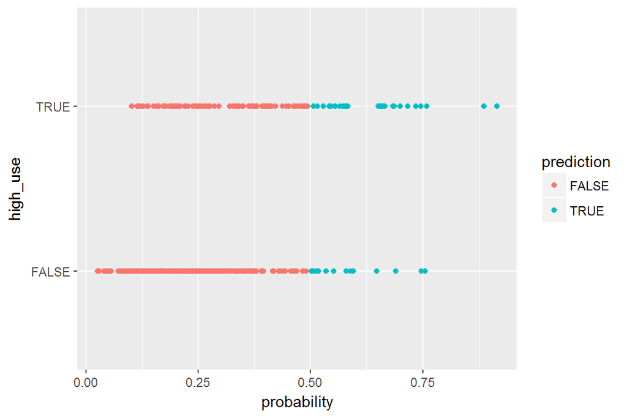

```r
g <- ggplot(alc, aes(x = probability, y = high_use, col=prediction))
g + geom_point()
```

```r
table(high_use = alc$high_use, prediction = alc$prediction)%>%prop.table()%>%addmargins()
```

```
##         prediction
## high_use      FALSE       TRUE        Sum
##    FALSE 0.65183246 0.04973822 0.70157068
##    TRUE  0.22513089 0.07329843 0.29842932
##    Sum   0.87696335 0.12303665 1.00000000
```

From the analyses above we conclude that the model has quite high accuracy (72%), but we should keep in mind that we have not used any additional data.

Next we define a loss function (mean prediction error) as:

```r
loss_func <- function(class, prob) {
  n_wrong <- abs(class - prob) > 0.5
  mean(n_wrong)
}
```

and call it to compute the average number of wrong predictions in the (training) data

```r
loss_func(class = alc$high_use, prob = alc$probability)
```

```
## [1] 0.2748691
```

## Used and useful links

[Contingency tables (cross-tabulation), used for preliminary determining dependence of two variables] (https://en.wikipedia.org/wiki/Contingency_table https://www.qualtrics.com/wp-content/uploads/2013/05/Cross-Tabulation-Theory.pdf https://qualityandinnovation.com/2015/02/08/contingency-tables-with-gmodels/)

[Logit regression] (http://www.ats.ucla.edu/stat/r/dae/logit.htm)

[An Introduction to Statistical Learning with Applications in R, Gareth James, Daniela Witten, Trevor Hastie and Robert Tibshirani, Springer, 2013] (http://www-bcf.usc.edu/~gareth/ISL/)

[Cross-Validation for Predictive Analytics Using R](https://www.r-bloggers.com/cross-validation-for-predictive-analytics-using-r/)

## Link to to the GitHub page, related to my work on this course:

https://github.com/noykova/IODS-project

# 4. Clustering and classification

## 4.1. Reading the data

In this chapter we use the data about crime rate in the suburbs of Boston for developing classification and clustering models.

## 4.2. Summary and correlation analysis of the Boston data.

The summary of data and its structure are given as:

```r
library(MASS)
```

```r
library(tidyr);
library(dplyr);
library(ggplot2)
library(corrplot)

data("Boston")

str(Boston)
```

```
## 'data.frame':    506 obs. of  14 variables:
##  $ crim   : num  0.00632 0.02731 0.02729 0.03237 0.06905 ...
##  $ zn     : num  18 0 0 0 0 0 12.5 12.5 12.5 12.5 ...
##  $ indus  : num  2.31 7.07 7.07 2.18 2.18 2.18 7.87 7.87 7.87 7.87 ...
##  $ chas   : int  0 0 0 0 0 0 0 0 0 0 ...
##  $ nox    : num  0.538 0.469 0.469 0.458 0.458 0.458 0.524 0.524 0.524 0.524 ...
##  $ rm     : num  6.58 6.42 7.18 7 7.15 ...
##  $ age    : num  65.2 78.9 61.1 45.8 54.2 58.7 66.6 96.1 100 85.9 ...
##  $ dis    : num  4.09 4.97 4.97 6.06 6.06 ...
##  $ rad    : int  1 2 2 3 3 3 5 5 5 5 ...
##  $ tax    : num  296 242 242 222 222 222 311 311 311 311 ...
##  $ ptratio: num  15.3 17.8 17.8 18.7 18.7 18.7 15.2 15.2 15.2 15.2 ...
##  $ black  : num  397 397 393 395 397 ...
##  $ lstat  : num  4.98 9.14 4.03 2.94 5.33 ...
##  $ medv   : num  24 21.6 34.7 33.4 36.2 28.7 22.9 27.1 16.5 18.9 ...
```

```r
summary(Boston)
```

```
##       crim                zn             indus            chas
##  Min.   : 0.00632   Min.   :  0.00   Min.   : 0.46   Min.   :0.00000
##  1st Qu.: 0.08204   1st Qu.:  0.00   1st Qu.: 5.19   1st Qu.:0.00000
##  Median : 0.25651   Median :  0.00   Median : 9.69   Median :0.00000
##  Mean   : 3.61352   Mean   : 11.36   Mean   :11.14   Mean   :0.06917
##  3rd Qu.: 3.67708   3rd Qu.: 12.50   3rd Qu.:18.10   3rd Qu.:0.00000
##  Max.   :88.97620   Max.   :100.00   Max.   :27.74   Max.   :1.00000
##       nox               rm             age              dis
##  Min.   :0.3850   Min.   :3.561   Min.   :  2.90   Min.   : 1.130
##  1st Qu.:0.4490   1st Qu.:5.886   1st Qu.: 45.02   1st Qu.: 2.100
##  Median :0.5380   Median :6.208   Median : 77.50   Median : 3.207
##  Mean   :0.5547   Mean   :6.285   Mean   : 68.57   Mean   : 3.795
##  3rd Qu.:0.6240   3rd Qu.:6.623   3rd Qu.: 94.08   3rd Qu.: 5.188
##  Max.   :0.8710   Max.   :8.780   Max.   :100.00   Max.   :12.127
##       rad              tax           ptratio          black
##  Min.   : 1.000   Min.   :187.0   Min.   :12.60   Min.   :  0.32
##  1st Qu.: 4.000   1st Qu.:279.0   1st Qu.:17.40   1st Qu.:375.38
##  Median : 5.000   Median :330.0   Median :19.05   Median :391.44
##  Mean   : 9.549   Mean   :408.2   Mean   :18.46   Mean   :356.67
##  3rd Qu.:24.000   3rd Qu.:666.0   3rd Qu.:20.20   3rd Qu.:396.23
##  Max.   :24.000   Max.   :711.0   Max.   :22.00   Max.   :396.90
##      lstat            medv
##  Min.   : 1.73   Min.   : 5.00
##  1st Qu.: 6.95   1st Qu.:17.02
##  Median :11.36   Median :21.20
##  Mean   :12.65   Mean   :22.53
##  3rd Qu.:16.95   3rd Qu.:25.00
##  Max.   :37.97   Max.   :50.00
```

```r
glimpse(Boston)
```

```
## Observations: 506
## Variables: 14
## $ crim    <dbl> 0.00632, 0.02731, 0.02729, 0.03237, 0.06905, 0.02985, ...
## $ zn      <dbl> 18.0, 0.0, 0.0, 0.0, 0.0, 0.0, 12.5, 12.5, 12.5, 12.5,...
## $ indus   <dbl> 2.31, 7.07, 7.07, 2.18, 2.18, 2.18, 7.87, 7.87, 7.87, ...
## $ chas    <int> 0, 0, 0, 0, 0, 0, 0, 0, 0, 0, 0, 0, 0, 0, 0, 0, 0, 0, ...
## $ nox     <dbl> 0.538, 0.469, 0.469, 0.458, 0.458, 0.458, 0.524, 0.524...
## $ rm      <dbl> 6.575, 6.421, 7.185, 6.998, 7.147, 6.430, 6.012, 6.172...
## $ age     <dbl> 65.2, 78.9, 61.1, 45.8, 54.2, 58.7, 66.6, 96.1, 100.0,...
## $ dis     <dbl> 4.0900, 4.9671, 4.9671, 6.0622, 6.0622, 6.0622, 5.5605...
## $ rad     <int> 1, 2, 2, 3, 3, 3, 5, 5, 5, 5, 5, 5, 5, 4, 4, 4, 4, 4, ...
## $ tax     <dbl> 296, 242, 242, 222, 222, 222, 311, 311, 311, 311, 311,...
## $ ptratio <dbl> 15.3, 17.8, 17.8, 18.7, 18.7, 18.7, 15.2, 15.2, 15.2, ...
## $ black   <dbl> 396.90, 396.90, 392.83, 394.63, 396.90, 394.12, 395.60...
## $ lstat   <dbl> 4.98, 9.14, 4.03, 2.94, 5.33, 5.21, 12.43, 19.15, 29.9...
## $ medv    <dbl> 24.0, 21.6, 34.7, 33.4, 36.2, 28.7, 22.9, 27.1, 16.5, ...
```

Preliminary analysis of data is based on: - plot matrix of variables:

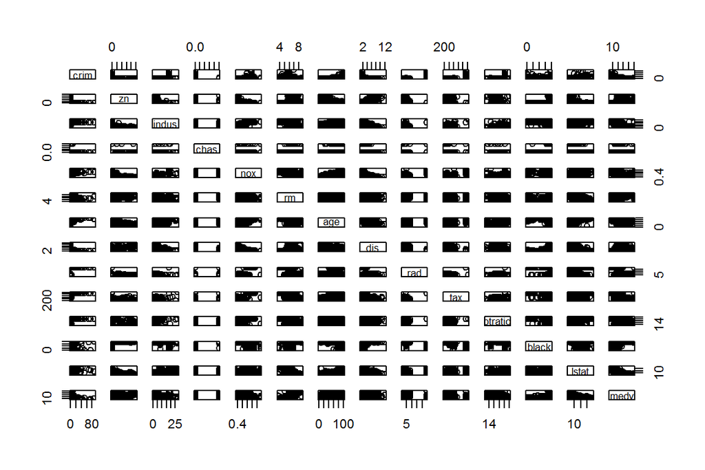

```r
pairs(Boston)
```

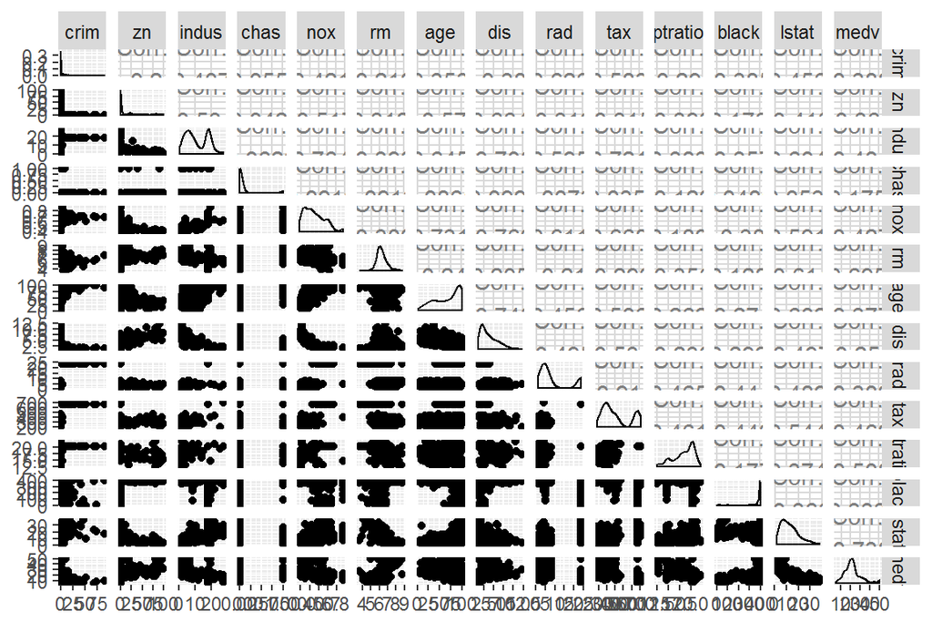

```r
library(GGally)
ggpairs(Boston, diag=list(continuous="density", discrete="bar"), axisLabels="show")
```

- numerical values of corrrelation matrix:

```r
cor_matrix<-cor(Boston) %>% round(digits =2)
cor_matrix
```

```
##          crim    zn indus  chas   nox    rm   age   dis   rad   tax
## crim     1.00 -0.20  0.41 -0.06  0.42 -0.22  0.35 -0.38  0.63  0.58
## zn      -0.20  1.00 -0.53 -0.04 -0.52  0.31 -0.57  0.66 -0.31 -0.31
## indus    0.41 -0.53  1.00  0.06  0.76 -0.39  0.64 -0.71  0.60  0.72
## chas    -0.06 -0.04  0.06  1.00  0.09  0.09  0.09 -0.10 -0.01 -0.04
## nox      0.42 -0.52  0.76  0.09  1.00 -0.30  0.73 -0.77  0.61  0.67
## rm      -0.22  0.31 -0.39  0.09 -0.30  1.00 -0.24  0.21 -0.21 -0.29
## age      0.35 -0.57  0.64  0.09  0.73 -0.24  1.00 -0.75  0.46  0.51
## dis     -0.38  0.66 -0.71 -0.10 -0.77  0.21 -0.75  1.00 -0.49 -0.53
## rad      0.63 -0.31  0.60 -0.01  0.61 -0.21  0.46 -0.49  1.00  0.91
## tax      0.58 -0.31  0.72 -0.04  0.67 -0.29  0.51 -0.53  0.91  1.00
## ptratio  0.29 -0.39  0.38 -0.12  0.19 -0.36  0.26 -0.23  0.46  0.46
## black   -0.39  0.18 -0.36  0.05 -0.38  0.13 -0.27  0.29 -0.44 -0.44
## lstat    0.46 -0.41  0.60 -0.05  0.59 -0.61  0.60 -0.50  0.49  0.54
## medv    -0.39  0.36 -0.48  0.18 -0.43  0.70 -0.38  0.25 -0.38 -0.47
##         ptratio black lstat  medv
## crim       0.29 -0.39  0.46 -0.39
## zn        -0.39  0.18 -0.41  0.36
## indus      0.38 -0.36  0.60 -0.48
## chas      -0.12  0.05 -0.05  0.18
## nox        0.19 -0.38  0.59 -0.43
## rm        -0.36  0.13 -0.61  0.70
## age        0.26 -0.27  0.60 -0.38
## dis       -0.23  0.29 -0.50  0.25
## rad        0.46 -0.44  0.49 -0.38
## tax        0.46 -0.44  0.54 -0.47
## ptratio    1.00 -0.18  0.37 -0.51
## black     -0.18  1.00 -0.37  0.33
## lstat      0.37 -0.37  1.00 -0.74
## medv      -0.51  0.33 -0.74  1.00
```

- graphical presentation of correlation matrix using correlogram

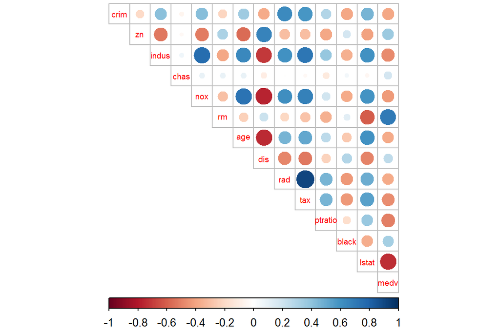

```r
library(corrplot)
corrplot(cor_matrix, method="circle", type = "upper", cl.pos = "b", tl.pos = "d", tl.cex = 0.6)
```

In this correlogram code visualization method is “circle” and layout “upper” display upper triangular of the correlation matrix.

We observe also higher correlation between some of the other variables, for example the variable *nox* (nitrogen oxides concentration) is highly correlated (corr >0.6) to *age*, *dis*, *rad*. We do not describe here all highly correlated variables because we focus on crime rate.

From the matrix plot we observe that only the variable *rm* has near to normal distribution.

The summary of the data shows that different variables have different ranges, so some rescaling further in the analysis could be reasonable. Therefore we continue applying data standardization.

## 4.3. Standardization of Boston data

Rescaling of column *x* is provided by subtracting the column means *mean(x)* from the corresponding columns and dividing the difference with standard deviation *sd(x)*.

*scale (x)=(x - mean(x))/sd(x)*

Since the Boston data contains only numerical values (also for both categorical variables) we can use the function *scale()* to standardize the whole dataset.

R code for center and standardization of data:

```r
boston_scaled <- scale(Boston, center = TRUE, scale = TRUE)
summary(boston_scaled)
```

```
##       crim                 zn               indus
##  Min.   :-0.419367   Min.   :-0.48724   Min.   :-1.5563
##  1st Qu.:-0.410563   1st Qu.:-0.48724   1st Qu.:-0.8668
##  Median :-0.390280   Median :-0.48724   Median :-0.2109
##  Mean   : 0.000000   Mean   : 0.00000   Mean   : 0.0000
##  3rd Qu.: 0.007389   3rd Qu.: 0.04872   3rd Qu.: 1.0150
##  Max.   : 9.924110   Max.   : 3.80047   Max.   : 2.4202
##       chas              nox                rm               age
##  Min.   :-0.2723   Min.   :-1.4644   Min.   :-3.8764   Min.   :-2.3331
##  1st Qu.:-0.2723   1st Qu.:-0.9121   1st Qu.:-0.5681   1st Qu.:-0.8366
##  Median :-0.2723   Median :-0.1441   Median :-0.1084   Median : 0.3171
##  Mean   : 0.0000   Mean   : 0.0000   Mean   : 0.0000   Mean   : 0.0000
##  3rd Qu.:-0.2723   3rd Qu.: 0.5981   3rd Qu.: 0.4823   3rd Qu.: 0.9059
##  Max.   : 3.6648   Max.   : 2.7296   Max.   : 3.5515   Max.   : 1.1164
##       dis               rad               tax             ptratio
##  Min.   :-1.2658   Min.   :-0.9819   Min.   :-1.3127   Min.   :-2.7047
##  1st Qu.:-0.8049   1st Qu.:-0.6373   1st Qu.:-0.7668   1st Qu.:-0.4876
##  Median :-0.2790   Median :-0.5225   Median :-0.4642   Median : 0.2746
##  Mean   : 0.0000   Mean   : 0.0000   Mean   : 0.0000   Mean   : 0.0000
##  3rd Qu.: 0.6617   3rd Qu.: 1.6596   3rd Qu.: 1.5294   3rd Qu.: 0.8058
##  Max.   : 3.9566   Max.   : 1.6596   Max.   : 1.7964   Max.   : 1.6372
##      black             lstat              medv
##  Min.   :-3.9033   Min.   :-1.5296   Min.   :-1.9063
##  1st Qu.: 0.2049   1st Qu.:-0.7986   1st Qu.:-0.5989
##  Median : 0.3808   Median :-0.1811   Median :-0.1449
##  Mean   : 0.0000   Mean   : 0.0000   Mean   : 0.0000
##  3rd Qu.: 0.4332   3rd Qu.: 0.6024   3rd Qu.: 0.2683
##  Max.   : 0.4406   Max.   : 3.5453   Max.   : 2.9865
```

We observe that now, after standardization, the mean of all variables is 0, which allow to compare directly the influence of all variables.

## 4.4. Linear discriminant analysis

Linear discriminant analysis (LDA) is used here to find a linear combination of features which characterizes and separates two or more classes of objects. The resulting combination is used as a linear classifier.

The goal of classification problem is to find a good predictor (expressed as linear combinations of the original variables) for the class *y* of any sample of the same distribution (not necessarily from the training set) given only an observation *x*. The model produces the best possible separation between the different classes.

As a first step we choose class *y* to be the crime rate in Boston dataset. We use the *cut* function to convert this continuous variable into a categorical. The **breaks** argument to **cut** describes how ranges of numbers are converted to factor values. We provide a vector of values, which values are used to determine the breakpoints. The number of levels of the resultant factor is one less than the number of values in the vector. We define this vector using **quantile()** function, executed on scaled continues variable **crime**.

```r
boston_scaled <- scale(Boston, center = TRUE, scale = TRUE)
class(boston_scaled)
```

```
## [1] "matrix"
```

```r
boston_scaled <- as.data.frame(boston_scaled)
scaled_crim <- boston_scaled$crim
summary(scaled_crim)
```

```
##      Min.   1st Qu.    Median      Mean   3rd Qu.      Max.
## -0.419400 -0.410600 -0.390300  0.000000  0.007389  9.924000
```

```r
bins <- quantile(scaled_crim)
bins
```

```
##           0%          25%          50%          75%         100%
## -0.419366929 -0.410563278 -0.390280295  0.007389247  9.924109610
```

```r
crime <- cut(scaled_crim, breaks = bins, labels = c("low", "med_low", "med_high", "high"), include.lowest = TRUE)
```

We look the table of categorical variable **y** to see how many observations are in every class:

```r
table(crime)
```

```
## crime
##      low  med_low med_high     high
##      127      126      126      127
```

Next we drop the old crime rate variable from the dataset and add the new categorical value to scaled data:

```r
boston_scaled <- dplyr::select(boston_scaled, -crim)
boston_scaled <- data.frame(boston_scaled, crime)
```

Since we like to use the model for prediction, we divide the dataset to train and test data sets, so that 80% of the data belongs to the train set. We choose randomly 80% of the rows for the training set, and rest of the data for testing.

```r
n <- nrow(boston_scaled)
ind <- sample(n,  size = n * 0.8)
train <- boston_scaled[ind,]
test <- boston_scaled[-ind,]
```

### 4.4.1 LDA modeling using training data

We want to separate the Boston data by crime rate, where the number of classes in C=4, and the number of variables is x = 13. The maximum number of useful discriminant functions that can separate the Boston data by crime rate is the minimum of C-1 and x, which in our case is the minimum of 3 and 13, which is 3. Thus, we can find at most 3 useful discriminant functions to separate the data by crime rate.

Linear discriminant model on training data produce the following results:

```r
lda.fit <- lda(crime ~ ., data = train)
lda.fit
```

```
## Call:
## lda(crime ~ ., data = train)
##
## Prior probabilities of groups:
##       low   med_low  med_high      high
## 0.2574257 0.2450495 0.2599010 0.2376238
##
## Group means:
##                  zn      indus        chas        nox          rm
## low       0.8712229 -0.8900991 -0.08304540 -0.8552027  0.44217953
## med_low  -0.1071928 -0.3302405 -0.07348562 -0.5597954 -0.14097084
## med_high -0.3802515  0.1853830  0.25261763  0.4301760  0.08750128
## high     -0.4872402  1.0149946 -0.02626030  1.0641856 -0.37022150
##                 age        dis        rad        tax     ptratio
## low      -0.8299932  0.8489068 -0.6837115 -0.7564337 -0.36586235
## med_low  -0.3548290  0.3026642 -0.5549663 -0.4929813 -0.09283751
## med_high  0.4268245 -0.4131735 -0.4087315 -0.3162735 -0.39253612
## high      0.8004355 -0.8386170  1.6596029  1.5294129  0.80577843
##                black       lstat        medv
## low       0.38472978 -0.76605797  0.52011370
## med_low   0.32637623 -0.15047880 -0.00521445
## med_high  0.08421343  0.03432644  0.17330024
## high     -0.77129054  0.85490898 -0.74326997
##
## Coefficients of linear discriminants:
##                  LD1          LD2         LD3
## zn       0.077469812  0.585651714 -0.89363673
## indus    0.002582126 -0.230178350  0.16767551
## chas    -0.079191514 -0.059496409 -0.01980242
## nox      0.249102086 -0.795136265 -1.27759569
## rm      -0.159505691 -0.066226223 -0.24187652
## age      0.340712266 -0.242103870 -0.21623983
## dis     -0.053705721 -0.127823780 -0.11315702
## rad      3.435356943  0.912992583 -0.26549986
## tax      0.038660187 -0.030529293  0.68313506
## ptratio  0.141982840  0.084729450 -0.28476531
## black   -0.171790159 -0.003720521  0.10895939
## lstat    0.175201187 -0.283848117  0.35371745
## medv     0.202383158 -0.439733862 -0.17053610
##
## Proportion of trace:
##    LD1    LD2    LD3
## 0.9541 0.0351 0.0108
```

For convenience the values for each discriminant function are scaled so that their mean value is zero and its variance is one.

Next we visualize results by using biplot function. For this purpose we have to transform classes to numeric and add function **lda.arrows** for drawing lda biplot arrows. The argument *dimen* in **plot()** function determines how many discriminants are used.

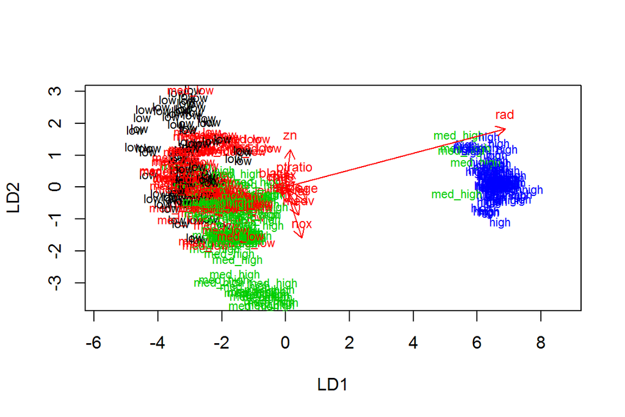

```r
lda.fit <- lda(crime ~ ., data = train)

lda.arrows <- function(x, myscale = 1, arrow_heads = 0.1, color = "red", tex = 0.75, choices = c(1,2)){
  heads <- coef(x)
  arrows(x0 = 0, y0 = 0,
         x1 = myscale * heads[,choices[1]],
         y1 = myscale * heads[,choices[2]], col=color, length = arrow_heads)
  text(myscale * heads[,choices], labels = row.names(heads),
       cex = tex, col=color, pos=3)
}

classes <- as.numeric(train$crime)

plot(lda.fit, dimen = 2, col = classes, pch = classes)
lda.arrows(lda.fit, myscale = 2)
```

The argument *myscale* in lda.arrows determines the length of arrows. By default, this plots arrows for the first and second axes. This LDA biplot shows good separation only about the class marked as “high”. All 3 other classes overlap quite a lot.

### 4.4.2 LDA for prediction: use of test data.

Now the task is to classify and calculate posterior probabilities of LDA model using new, unseen before data. In R this is calculated using a method **predict** for LDA objects. Here we use 20% of all data, which se separated to be test data. In order to analyze the model performance we use cross tabulation and create a table consisting of correct and predicted classes.

```r
lda.pred <- predict(lda.fit, newdata = test)
table(correct = test$crime, predicted = lda.pred$class)
```

```
##           predicted
## correct    low med_low med_high high
##   low       17       5        1    0
##   med_low    5      19        3    0
##   med_high   0       8       12    1
##   high       0       0        1   30
```

## 5. Distance measures and clustering. K-means algorithm

In clustering the number of classes is unknown, and the data are grouped based on their similarity. Here we apply the oldest *K-clustering* method. In order to be able to compare the results we use standardized Boston data. We use the most popular Eucledian distance as a measure how close are the observations. The **dist()** function creates a distance matrix consisting of pairwise distances of the observations. For large datasets its computation is time consuming and can need a lot of space.

```r
dist_eu <- dist(boston_scaled, method = "euclidean")
summary(dist_eu)
```

```
##    Min. 1st Qu.  Median    Mean 3rd Qu.    Max.
##  0.1394  3.5270  4.9080  4.9390  6.2420 13.0000
```

K-means **kmeans()**is an unsupervised method, that assigns observations to groups or clusters based on similarity of the objects. It takes as an argument the number of clusters to look:

```r
km <-kmeans(dist_eu, centers = 4)
```

One way to determine the number of clusters is to look at how the total of within cluster sum of squares (WCSS) behaves when the number of cluster changes. The optimal number of clusters is achieved when WCSS drops significantly.

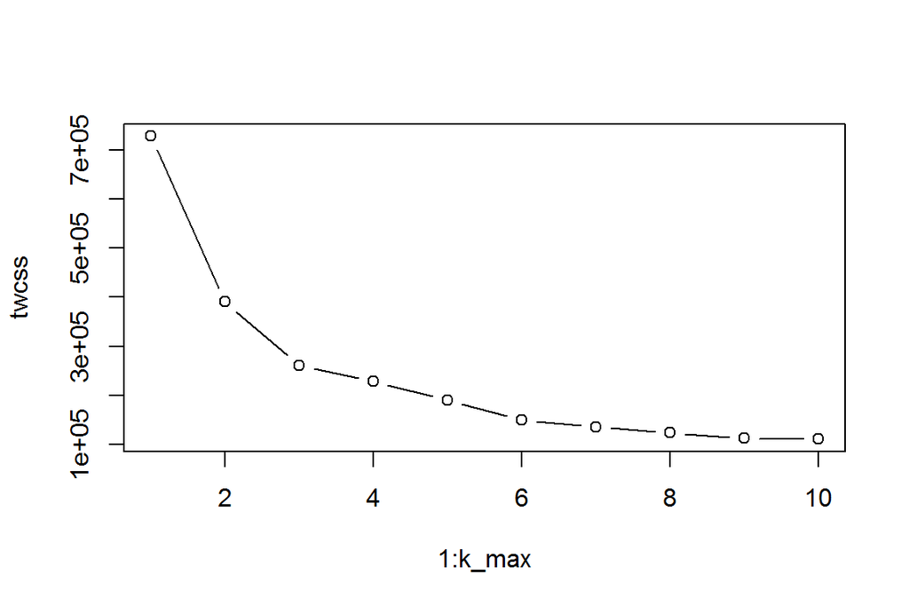

```r
set.seed(123)
k_max <- 10
twcss <- sapply(1:k_max, function(k){kmeans(dist_eu, k)$tot.withinss})
plot(1:k_max, twcss, type='b')
```

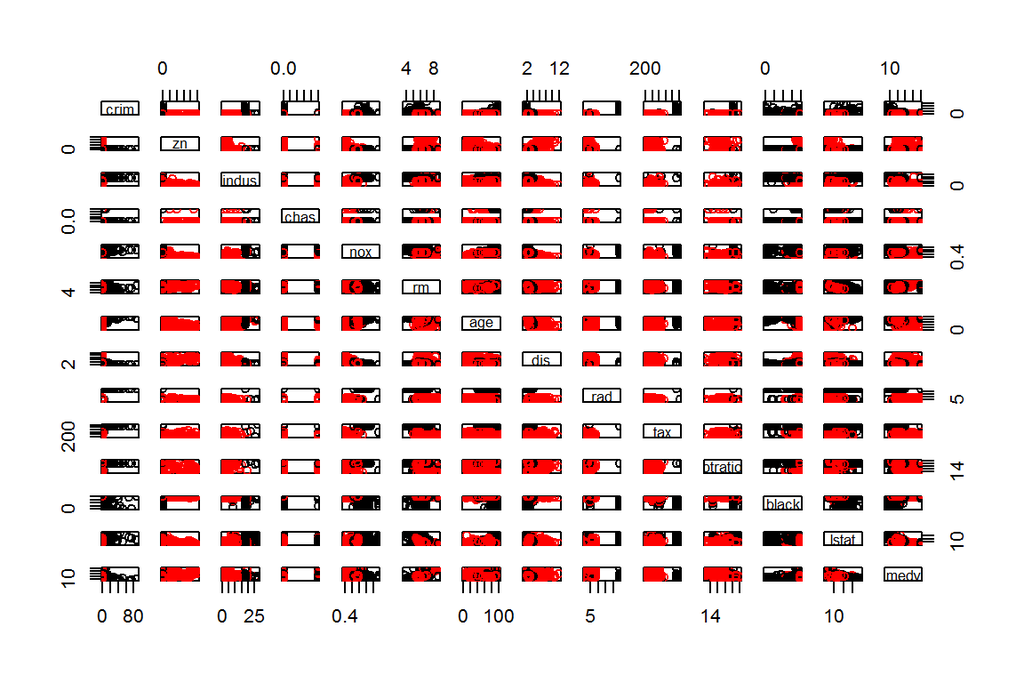

```r
km <-kmeans(dist_eu, centers = 2)
pairs(Boston, col = km$cluster)
```

## Used and useful links

[1. Data standardization](http://rtutorialseries.blogspot.fi/2012/03/r-tutorial-series-centering-variables.html) [2. Discriminant Analysis in R](https://rstudio-pubs-static.s3.amazonaws.com/35817_2552e05f1d4e4db8ba87b334101a43da.html) [3. Factors in R](https://www.stat.berkeley.edu/classes/s133/factors.html) [4. Biplots for LDA in R](http://stackoverflow.com/questions/17232251/how-can-i-plot-a-biplot-for-lda-in-r) [5. K means clustering](https://www.r-bloggers.com/k-means-clustering-in-r/)(https://rpubs.com/FelipeRego/K-Means-Clustering) [6. 3D plots using plotly](https://gist.github.com/cpsievert/18b68d0daefbf635fbd3)

# 5. Dimensionality reduction technique

## 5.1. The data

In this chapter we use **human** data from the United Nations Development Programme, which are originally published [here](http://hdr.undp.org/en/content/human-development-index-hdi). The data concern so called human development index (HDI) as a criteria for the development of a country. HDI is a summary measure of three main groups of variables about long and healthy life, being knowledgeable and have a decent standard of living. Original data include 195 observations of 19 variables. The meaning of all variables is described [here](https://raw.githubusercontent.com/TuomoNieminen/Helsinki-Open-Data-Science/master/datasets/human_meta.txt).

The wrangling includes the following changes:

1. Two new columns are added to “Gender inequality” data: the ratio of Female and Male populations with secondary education in each country. (i.e. edu2F / edu2M), and the second one - the ratio of labour force participation of females and males in each country (i.e. labF / labM).
2. Next “Gender inequality” and “Human development” datas are joined using the variable Country as the identifier.
3. The variable GNi is transformed to numeric. Only the columns c(“Country”, “Edu2.FM”, “Labo.FM”, “Edu.Exp”, “Life.Exp”, “GNI”, “Mat.Mor”, “Ado.Birth”, “Parli.F”) are selected for further work.
4. The rows with missing values are removed. The last 10 observations relate to regions instead of countries. Therefore they are removed.
5. Finally the country names are added as rownames and the corresponding ciolumn is removed from data frame.

The transformed data involve 155 observations of 8 variables.

## 5.2.Graphical overview of the data and summaries of the variables

The preliminary treated data look as:

```r
human= read.csv("human.csv")
str(human)
```

```
## 'data.frame':    155 obs. of  9 variables:
##  $ X        : Factor w/ 155 levels "Afghanistan",..: 105 6 134 41 101 54 67 149 28 102 ...
##  $ Edu2.FM  : num  1.007 0.997 0.983 0.989 0.969 ...
##  $ Labo.FM  : num  0.891 0.819 0.825 0.884 0.829 ...
##  $ Edu.Exp  : num  17.5 20.2 15.8 18.7 17.9 16.5 18.6 16.5 15.9 19.2 ...
##  $ Life.Exp : num  81.6 82.4 83 80.2 81.6 80.9 80.9 79.1 82 81.8 ...
##  $ GNI      : int  64992 42261 56431 44025 45435 43919 39568 52947 42155 32689 ...
##  $ Mat.Mor  : int  4 6 6 5 6 7 9 28 11 8 ...
##  $ Ado.Birth: num  7.8 12.1 1.9 5.1 6.2 3.8 8.2 31 14.5 25.3 ...
##  $ Parli.F  : num  39.6 30.5 28.5 38 36.9 36.9 19.9 19.4 28.2 31.4 ...
```

```r
head(human)
```

```
##             X   Edu2.FM   Labo.FM Edu.Exp Life.Exp   GNI Mat.Mor Ado.Birth
## 1      Norway 1.0072389 0.8908297    17.5     81.6 64992       4       7.8
## 2   Australia 0.9968288 0.8189415    20.2     82.4 42261       6      12.1
## 3 Switzerland 0.9834369 0.8251001    15.8     83.0 56431       6       1.9
## 4     Denmark 0.9886128 0.8840361    18.7     80.2 44025       5       5.1
## 5 Netherlands 0.9690608 0.8286119    17.9     81.6 45435       6       6.2
## 6     Germany 0.9927835 0.8072289    16.5     80.9 43919       7       3.8
##   Parli.F
## 1    39.6
## 2    30.5
## 3    28.5
## 4    38.0
## 5    36.9
## 6    36.9
```

Next we use ggpairs() for creating advanced plot matrix.

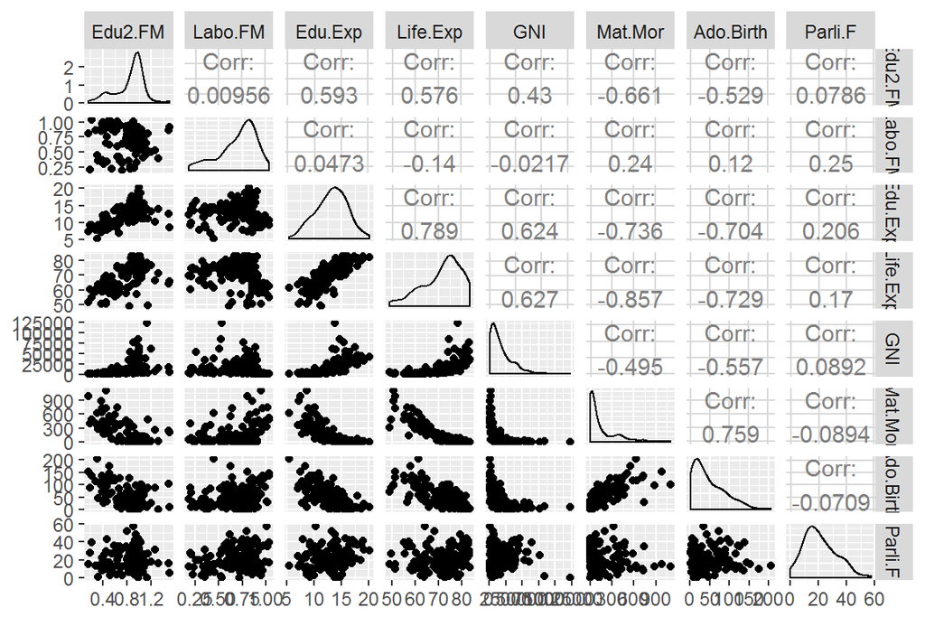

```r
library(dplyr)
library(corrplot)
library(GGally)
human_ <- dplyr::select(human, -X)
ggpairs(human_, diag=list(continuous="density", discrete="bar"), axisLabels="show")
```

We see that the only variable which has near to normal distribution is Edu.Exp. It is also highly correlated to almost all other variables. Edu2.FM also shows correlation to the other variables, but the correlation coefficients are smaller comparing to coreesponding correlation coefficients of Edu.Exp. Life.Exp is positevily correlated to GNI, and negatively to Mat.Mor and Ado.Birth. GNI and Math.Mor are also negatively correlated. Math.mor has strong positive correlaton with Ado.Birth.

More clearly these dependences are shown using corrplot():

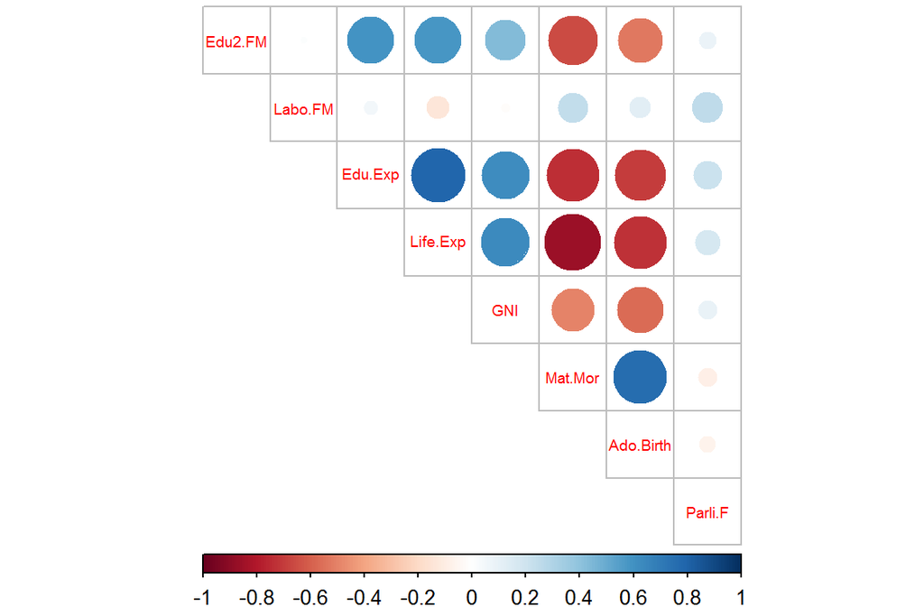

```r
cor_matrix<-cor(human_)%>% round(digits =2)
corrplot(cor_matrix, method="circle", type = "upper", cl.pos = "b", tl.pos = "d", tl.cex = 0.6)
```

## 5.3.Principal component analysis (PCA) on non- standardized and standardized data.

In this chapter we explore two methods for unsupervised learning - Principal component analysis and correspondence analysis. In the unsupervised learning we have only a set of features X1,X2, . . . , Xp measured on n observations. We do not have an associated response variable Y. Therefore here we are not interesting in the prediction. The goal is to discover interesting relations among the measurements on X1,X2, . . .,Xp. PCA is a tool used for data visualization or data pre-processing before applying methods for supervised learning. Here we apply this technique for dimensionality reduction. It is performed by singular value matrix decomposition method known from linear algebra. The data is transformed to new space with equal or less number of dimensions, called principal components. Principal components are expressed by relationships involving the original features X1,X2, . . .,Xp. Principal components are uncorrelated and each is less important than the previous one in terms of captured variance.

### 5.3.1 Non standardized data

First we perform PCA on the not standardized human data.

```r
pca_human <- prcomp(human_)
```

The results of PCA are visualized using biplots. These are scatter plots where observations are placed on x and y coordinates defined by first two principal components PC1 and PC2. Arrows and labels on these plots represent the connections between original features and principal components. The length of the arrows are proportional to the standard deviations of X1,X2, . . .,Xp. The angle between a feature and a PC axis corresponds to correlation of its arrows. Small angle corresponds to high positive correlation. Analogously the angle between arrows corresponds to the correlation between two features.

The biplot of PCA on non-standardized human datais obtain using biplot() function.

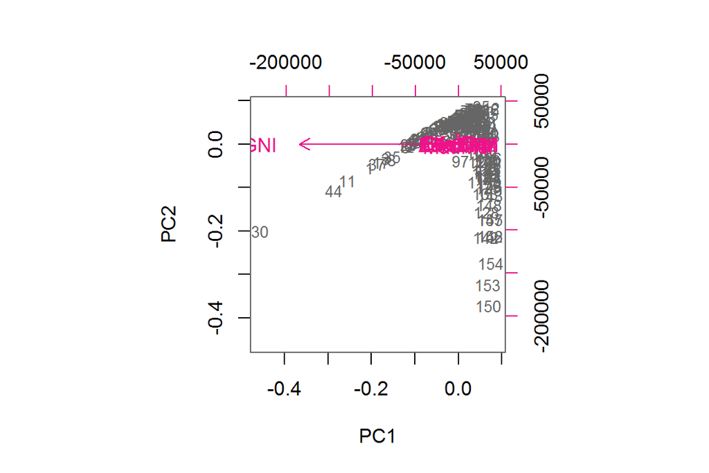

```r
biplot(pca_human, choices = 1:2, cex = c(0.8, 1), col = c("grey40", "deeppink2"))
```

The points marked in grey are the number of observations, which corresponds to the different countries, while arrows show the standard deviation of the corresponding feature.

It is difficult to analize this plot because the different dimensions of the investigated features. We observed the highest impact on PC1 has the variable GNI. This highest correlation is negative.

### 5.3.2 Standardized data

Next we apply standardization to X1,X2, . . .,Xp.

```r
human_std <- scale(human_)
summary(human_std)
```

```
##     Edu2.FM           Labo.FM           Edu.Exp           Life.Exp
##  Min.   :-2.8189   Min.   :-2.6247   Min.   :-2.7378   Min.   :-2.7188
##  1st Qu.:-0.5233   1st Qu.:-0.5484   1st Qu.:-0.6782   1st Qu.:-0.6425
##  Median : 0.3503   Median : 0.2316   Median : 0.1140   Median : 0.3056
##  Mean   : 0.0000   Mean   : 0.0000   Mean   : 0.0000   Mean   : 0.0000
##  3rd Qu.: 0.5958   3rd Qu.: 0.7350   3rd Qu.: 0.7126   3rd Qu.: 0.6717
##  Max.   : 2.6646   Max.   : 1.6632   Max.   : 2.4730   Max.   : 1.4218
##       GNI             Mat.Mor          Ado.Birth          Parli.F
##  Min.   :-0.9193   Min.   :-0.6992   Min.   :-1.1325   Min.   :-1.8203
##  1st Qu.:-0.7243   1st Qu.:-0.6496   1st Qu.:-0.8394   1st Qu.:-0.7409
##  Median :-0.3013   Median :-0.4726   Median :-0.3298   Median :-0.1403
##  Mean   : 0.0000   Mean   : 0.0000   Mean   : 0.0000   Mean   : 0.0000
##  3rd Qu.: 0.3712   3rd Qu.: 0.1932   3rd Qu.: 0.6030   3rd Qu.: 0.6127
##  Max.   : 5.6890   Max.   : 4.4899   Max.   : 3.8344   Max.   : 3.1850
```

The function scale()=(x-mean(x))/sd(x). Therefore the mean of standardized data is 0, and their standard deviation is 1.

In contrast with linear regression, in which scaling the variables has no effect, here scaling change results.

In linear regression multiplying a variable by a factor of c will lead to multiplication of the corresponding coefficient estimate by a factor of 1/c.

In PCA the situation is different because the different scaling factors will directly influence calculation of each PC components. As we have observed on biplot above, when dimensions are different, the absolute values of variances also differ a lot. Then the first principal component loading vector have a very large loading for GNI, since this variable has the highest variance.

We provide PCA using scaled data.

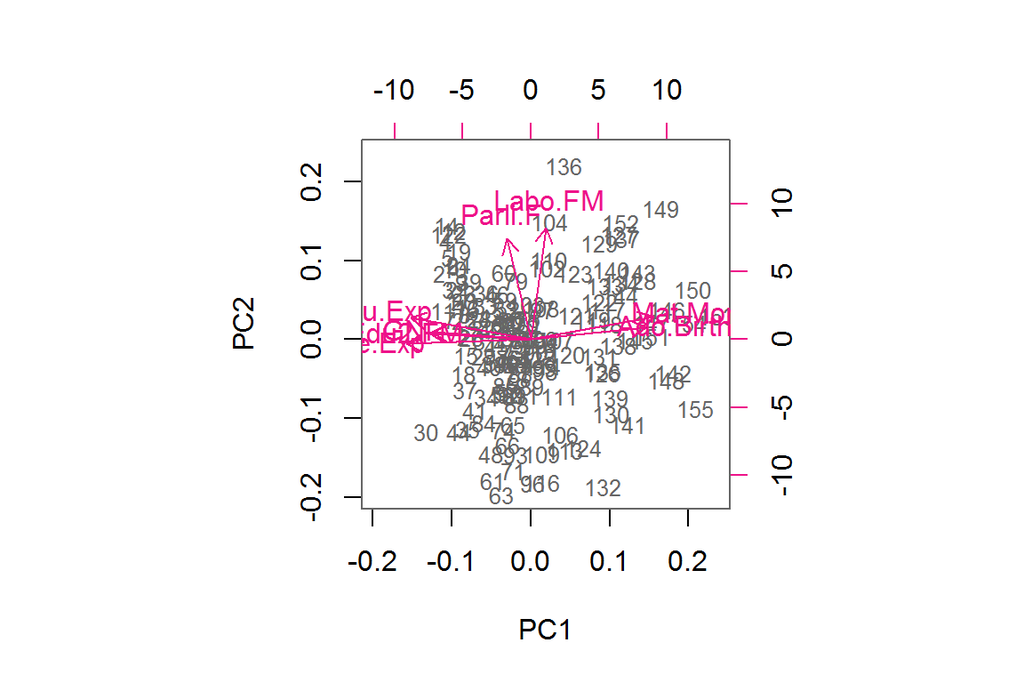

```r
pca_human <- prcomp(human_std)
biplot(pca_human, choices = 1:2, cex = c(0.8, 1), col = c("grey40", "deeppink2"))
```

After comparing last two biplots we see that the scaling has substantial effect on the results. Because it is undesirable for the principal components obtained to depend on an arbitrary choice of scaling, we typically scale each variable to have standard deviation one before we perform PCA.

The results of last biplot shows that Mat.Mor is highly correlated to PC1, while Parli.F is highly correlated to PC2. We can assume that correlation between these original features is negligible. So, we conclude that PC1 places most of its weight on Mat.Mor, while PC2 places most of its weight on Parli.F. We observe also high correlation between Mat.Mor, Ado.Birth, Edu.Exp, Edu2.FM, Life.Exp and GNi, which was also shown on correlation matrix plot. Here we see that the observations on right hand side of this biplot involve countries, where the maternal mortality ratio and adolescent birth rate are high, but (since the negative correlation) in the same time the Gross National Income per capita, expected years of schooling, the ratio between females and males with at least secondary education, and life expectancy at birth are low. On the left hand side of this biplot we see the opposite situation - the countries where the maternal mortality ratio and adolescent birth rate are low, and in the same time the Gross National Income per capita, expected years of schooling, the ratio between females and males with at least secondary education, and life expectancy at birth are high. On the upper part of this plot we see the countries where the proportion of female and male on the labour market is high, and also the percentage of female presentation in the parliament is high. The opposite situation is observed on the bottom part of this biplot. Therefore we can conclude that the best situation where we expect high human development index is in the countries, which are situated on the left upper side of this biplot.

We take a look on summary of PCA:

```r
s <- summary(pca_human)
s
```

```
## Importance of components:
##                           PC1    PC2     PC3     PC4     PC5     PC6
## Standard deviation     2.0708 1.1397 0.87505 0.77886 0.66196 0.53631
## Proportion of Variance 0.5361 0.1624 0.09571 0.07583 0.05477 0.03595
## Cumulative Proportion  0.5361 0.6984 0.79413 0.86996 0.92473 0.96069
##                            PC7     PC8
## Standard deviation     0.45900 0.32224
## Proportion of Variance 0.02634 0.01298
## Cumulative Proportion  0.98702 1.00000
```

and round the percetange of variance captured by each PC.

```r
pca_pr <- round(1*s$importance[2, ]*100, digits = 1)
pca_pr
```

```
##  PC1  PC2  PC3  PC4  PC5  PC6  PC7  PC8
## 53.6 16.2  9.6  7.6  5.5  3.6  2.6  1.3
```

Finally we add these percetanges of variance on the biplot

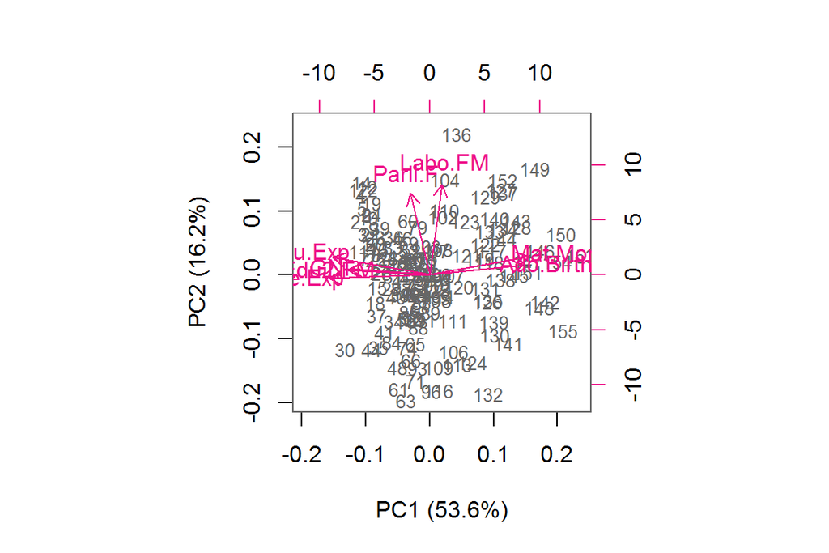

```r
pc_lab <- paste0(names(pca_pr), " (", pca_pr, "%)")
biplot(pca_human, cex = c(0.8, 1), col = c("grey40", "deeppink2"), xlab = pc_lab[1], ylab = pc_lab[2])
```

With this new information we have answer to the question how much of the information in human data set is lost by projecting the observations onto the first two principal components? The amount of variance, which is not contained in PC1 + PC2 = 100 - (53,6 + 16,2) = 30,2 %.